# Part I - Ford GoBike Data exploration

## Introduction

> Ford GoBike System Data: This data set includes information about individual rides made in a bike-sharing system covering the greater San Francisco Bay area with +180k instances.

## Preliminary Wrangling

```python
!pip install -U pandas
```

[output not shown]

```python
!pip install -U seaborn
```

[output not shown]

```python
# import all packages and set plots to be embedded inline
import numpy as np
import pandas as pd
import matplotlib.pyplot as plt
import seaborn as sb

%matplotlib inline
```

```python
df1 = pd.read_csv('201902-fordgobike-tripdata.csv')
print(df1.shape)
print(df1.dtypes)
print(df1.describe())
df1.head()
```

```
(183412, 16)
duration_sec                 int64
start_time                  object
end_time                    object
start_station_id           float64
start_station_name          object
start_station_latitude     float64
start_station_longitude    float64
end_station_id             float64
end_station_name            object
end_station_latitude       float64
end_station_longitude      float64
bike_id                      int64
user_type                   object
member_birth_year          float64
member_gender               object
bike_share_for_all_trip     object
dtype: object
        duration_sec  start_station_id  start_station_latitude  \
count  183412.000000     183215.000000           183412.000000
mean      726.078435        138.590427               37.771223
std      1794.389780        111.778864                0.099581
min        61.000000          3.000000               37.317298
25%       325.000000         47.000000               37.770083
50%       514.000000        104.000000               37.780760
75%       796.000000        239.000000               37.797280
max     85444.000000        398.000000               37.880222

       start_station_longitude  end_station_id  end_station_latitude  \
count            183412.000000   183215.000000         183412.000000
mean               -122.352664      136.249123             37.771427
std                   0.117097      111.515131              0.099490
min                -122.453704        3.000000             37.317298
25%                -122.412408       44.000000             37.770407
50%                -122.398285      100.000000             37.781010
75%                -122.286533      235.000000             37.797320
max                -121.874119      398.000000             37.880222

       end_station_longitude        bike_id  member_birth_year
count          183412.000000  183412.000000      175147.000000
mean             -122.352250    4472.906375        1984.806437
std                 0.116673    1664.383394          10.116689
min              -122.453704      11.000000        1878.000000
25%              -122.411726    3777.000000        1980.000000
50%              -122.398279    4958.000000        1987.000000
75%              -122.288045    5502.000000        1992.000000
max              -121.874119    6645.000000        2001.000000
```

|  | duration_sec | start_time | end_time | start_station_id | start_station_name | start_station_latitude | start_station_longitude | end_station_id | end_station_name | end_station_latitude | end_station_longitude | bike_id | user_type | member_birth_year | member_gender | bike_share_for_all_trip |
| --- | --- | --- | --- | --- | --- | --- | --- | --- | --- | --- | --- | --- | --- | --- | --- | --- |
| 0 | 52185 | 2019-02-28 17:32:10.1450 | 2019-03-01 08:01:55.9750 | 21.0 | Montgomery St BART Station (Market St at 2nd St) | 37.789625 | -122.400811 | 13.0 | Commercial St at Montgomery St | 37.794231 | -122.402923 | 4902 | Customer | 1984.0 | Male | No |
| 1 | 42521 | 2019-02-28 18:53:21.7890 | 2019-03-01 06:42:03.0560 | 23.0 | The Embarcadero at Steuart St | 37.791464 | -122.391034 | 81.0 | Berry St at 4th St | 37.775880 | -122.393170 | 2535 | Customer | NaN | NaN | No |
| 2 | 61854 | 2019-02-28 12:13:13.2180 | 2019-03-01 05:24:08.1460 | 86.0 | Market St at Dolores St | 37.769305 | -122.426826 | 3.0 | Powell St BART Station (Market St at 4th St) | 37.786375 | -122.404904 | 5905 | Customer | 1972.0 | Male | No |
| 3 | 36490 | 2019-02-28 17:54:26.0100 | 2019-03-01 04:02:36.8420 | 375.0 | Grove St at Masonic Ave | 37.774836 | -122.446546 | 70.0 | Central Ave at Fell St | 37.773311 | -122.444293 | 6638 | Subscriber | 1989.0 | Other | No |
| 4 | 1585 | 2019-02-28 23:54:18.5490 | 2019-03-01 00:20:44.0740 | 7.0 | Frank H Ogawa Plaza | 37.804562 | -122.271738 | 222.0 | 10th Ave at E 15th St | 37.792714 | -122.248780 | 4898 | Subscriber | 1974.0 | Male | Yes |

```python
df1.isna().sum()
```

```
duration_sec                  0
start_time                    0
end_time                      0
start_station_id            197
start_station_name          197
start_station_latitude        0
start_station_longitude       0
end_station_id              197
end_station_name            197
end_station_latitude          0
end_station_longitude         0
bike_id                       0
user_type                     0
member_birth_year          8265
member_gender              8265
bike_share_for_all_trip       0
dtype: int64
```

```python
# Get the count of unique values for each column
unique_counts = df1.nunique()

# Print the unique counts for each column
print(unique_counts)
```

```
duration_sec                 4752
start_time                 183401
end_time                   183397
start_station_id              329
start_station_name            329
start_station_latitude        334
start_station_longitude       335
end_station_id                329
end_station_name              329
end_station_latitude          335
end_station_longitude         335
bike_id                      4646
user_type                       2
member_birth_year              75
member_gender                   3
bike_share_for_all_trip         2
dtype: int64
```

```python
df1.user_type.value_counts()
```

```
Subscriber    163544
Customer       19868
Name: user_type, dtype: int64
```

```python
df1.bike_share_for_all_trip.value_counts()
```

```
No     166053
Yes     17359
Name: bike_share_for_all_trip, dtype: int64
```

```python
# Convert the start_time column to datetime format
df1['start_time'] = pd.to_datetime(df1['start_time'])

# Extract the hour from the start_time column
df1['start_hour'] = df1['start_time'].dt.hour

# Filter only the trips that happened during the day (between 6am and 9pm)
df1 = df1[(df1['start_hour'] >= 6) & (df1['start_hour'] <= 21)]
```

### What is the structure of your dataset?

> The Ford GoBike System Data is a CSV (comma-separated values) file that contains trip data for the Ford GoBike bike-sharing service. The dataset contains 16 columns and over 180k rows of data. Here is a brief description of each column in the dataset:
> - duration_sec: the duration of the trip in seconds
> - start_time: the date and time when the trip started
> - end_time: the date and time when the trip ended
> - start_station_id: the ID of the starting station
> - start_station_name: the name of the starting station
> - start_station_latitude: the latitude of the starting station
> - start_station_longitude: the longitude of the starting station
> - end_station_id: the ID of the ending station
> - end_station_name: the name of the ending station
> - end_station_latitude: the latitude of the ending station
> - end_station_longitude: the longitude of the ending station
> - bike_id: the ID of the bike used for the trip
> - user_type: the type of user (subscriber or customer)
> - member_birth_year: the birth year of the user (if available)
> - member_gender: the gender of the user (if available)
> - bike_share_for_all_trip: whether the user was enrolled in the Bike Share for All program for low-income residents

### What is/are the main feature(s) of interest in your dataset?

> Trip duration: this feature can provide insights into how long users typically ride the bikes, which can inform decisions around bike availability, pricing, and user satisfaction.

> User demographics: features such as user type (e.g. customer vs. subscriber), gender, and age can help understand who is using the bike-sharing service and whether there are any differences in usage patterns or preferences between different user groups.

> Most popular stations: features such as start_station_name can help to answer this question

### What features in the dataset do you think will help support your investigation into your feature(s) of interest?

> For the trip duration question features such as (duration_sec, start_time, end_time) can help to answer this quetion

> For User demographics: features such as user_type, member_gender, member_birth_year, and bike_share_for_all_trip can provide insights into user demographics and preferences. For example, analyzing the distribution of user types can help understand the proportion of subscribers vs. one-time customers using the bike-sharing service, while analyzing the distribution of gender and age can help identify any patterns or differences in usage between different user groups.

> For Most popular stations features such as start_station could help to answer this answer and demonstrate how the instances are distributed

## Univariate Exploration

### What is the distribution of user types, and which user type is most popular?

```python
def count_plot(df1,x,default_color,xlabel,ylabel,title):
    # Create the countplot using seaborn
    sb.countplot(data=df1, x=x,color=default_color,order=df1[x].value_counts().index)

    # Set the plot labels
    plt.xlabel(xlabel)
    plt.ylabel(ylabel)
    plt.title(title)

    # Show the plot
    plt.show()
```

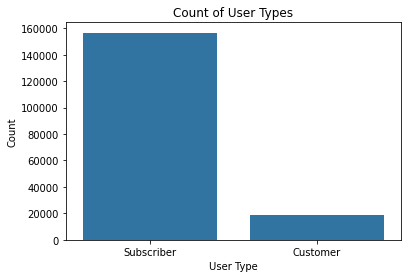

```python
default_color = sb.color_palette()[0]
x='user_type'
xlabel="User Type"
ylabel="Count"
title="Count of User Types"
# Create the countplot using seaborn
count_plot(df1,x,default_color,xlabel,ylabel,title)
```

The resulting plot will show two bars, one for subscriber and one for customer, representing the total number of trips taken by each user type. By examining the countplot, we can see that the subscriber user type is more popular than the customer user type, as there are more trips associated with the subscriber

### What is the most popular gender

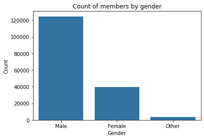

```python
default_color = sb.color_palette()[0]
x='member_gender'
xlabel="Gender"
ylabel="Count"
title="Count of members by gender"
# Create the countplot using seaborn
count_plot(df1,x,default_color,xlabel,ylabel,title)
```

The resulting plot shows three bars, one for each member_gender category (Male, Female, and Other), representing the total number of members associated with each gender. By examining the countplot, we can see that Male is the most popular member_gender, as there are more members associated with the Male bar compared to the other two bars.

### What are the most popular start stations

```python
def bar_plot(df1,x_groupby,default_color,xlabel,ylabel,title):
    station_counts = df1.groupby(x_groupby).size().reset_index(name='count')
    # Sort the results in descending order and select the top 10 stations
    top_stations = station_counts.sort_values(by='count', ascending=False).head(10)
    plt.figure(figsize=(15, 10))

    # Create the bar plot using seaborn
    sb.barplot(data=top_stations, y=x_groupby, x='count',color=default_color)

    # Set the plot labels
    plt.ylabel(ylabel)
    plt.xlabel(xlabel)
    plt.title(title)

    # Show the plot
    plt.show()
```

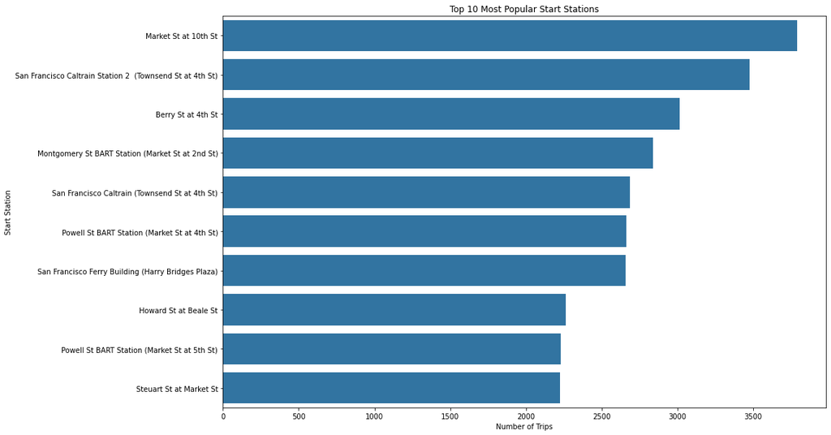

```python
x_groupby = 'start_station_name'
ylabel= 'Start Station'
xlabel= 'Number of Trips'
title= 'Top 10 Most Popular Start Stations'
bar_plot(df1,x_groupby,default_color,xlabel,ylabel,title)
```

The resulting plot shows a bar for each of the top 10 start stations by count of trips, ordered by count. By examining the countplot, we can see which stations have the highest counts of trips originating from them, and therefore are the most popular. We can see that Market st at 10th St is the most popular station

### Most popular end stations

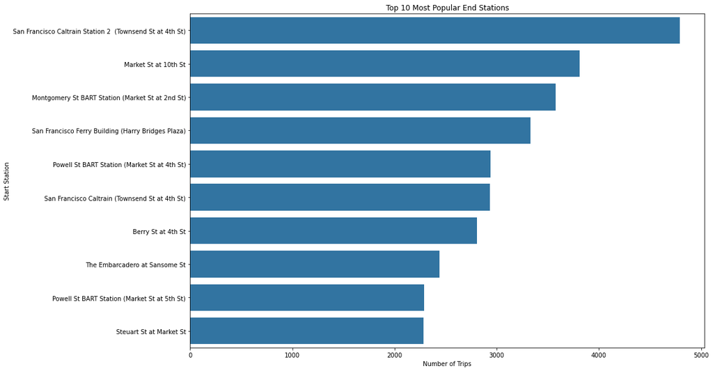

```python
x_groupby = 'end_station_name'
ylabel= 'Start Station'
xlabel= 'Number of Trips'
title= 'Top 10 Most Popular End Stations'
bar_plot(df1,x_groupby,default_color,xlabel,ylabel,title)
```

### Distribution of trips per start_hour

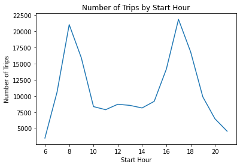

```python
# Create a groupby object by hour and count the number of trips per hour
hourly_trips = df1.groupby('start_hour').size()

# Plot the line plot using seaborn
sb.lineplot(x=hourly_trips.index, y=hourly_trips.values)

# Set the plot labels
plt.xlabel("Start Hour")
plt.ylabel("Number of Trips")
plt.title("Number of Trips by Start Hour")

# Show the plot
plt.show()
```

We can clearly see that the most popular time of trips is from 7am to 9 am and from 4pm to 6pm.

### What is the distribution of trips duration

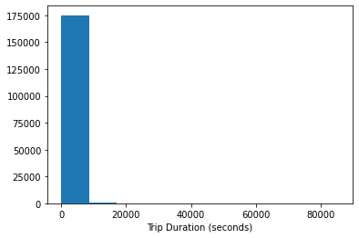

```python
plt.hist(data = df1, x = 'duration_sec')
plt.xlabel('Trip Duration (seconds)')
plt.show()
```

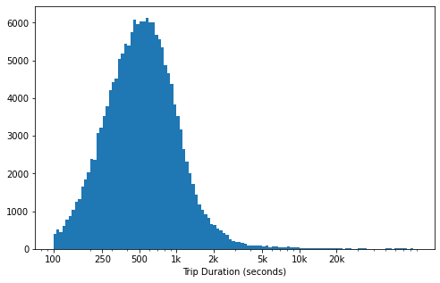

```python
# there's a long tail in the distribution, so let's put it on a log scale instead
log_binsize = 0.025
bins = 10 ** np.arange(2, np.log10(df1['duration_sec'].max())+log_binsize, log_binsize)

plt.figure(figsize=[8, 5])
plt.hist(data = df1, x = 'duration_sec', bins = bins)
plt.xscale('log')
plt.xticks([100,250,500, 1e3, 2e3, 5e3, 1e4, 2e4], [100,250,500, '1k', '2k', '5k', '10k', '20k'])
plt.xlabel('Trip Duration (seconds)')
plt.show()
```

We can notice that the most of distribution of trip duration is between 300 sec and 1500 sec, alghou there are some outliers that pass 10k seconds

### Count of trips for each day of week

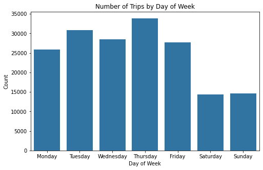

```python
df1['start_week_day'] = df1['start_time'].dt.day_name()

# convert cut, color, and clarity into ordered categorical types
ordinal_var = {'start_week_day': ['Monday','Tuesday','Wednesday','Thursday','Friday','Saturday','Sunday']}


ordinal_type = pd.api.types.CategoricalDtype(ordered = True,
                                                categories = ordinal_var['start_week_day'])
df1['start_week_day'] = df1['start_week_day'].astype(ordinal_type)
plt.figure(figsize=[8,5])
sb.countplot(data=df1, x='start_week_day', color=sb.color_palette()[0])
plt.xlabel('Day of Week')
plt.ylabel('Count')
plt.title('Number of Trips by Day of Week')
plt.show()
```

It seems that in the weekend there is less trips than the rest of the week, this might be cause by the fact that the trips are not all the time for fun or hanging around the city.

### What is the distribution of age of the members

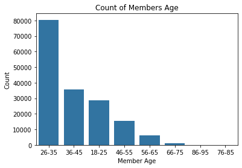

```python
# Define the bin edges and labels
df1['member_age'] = 2019 - df1['member_birth_year']
bin_edges = [18, 25, 35, 45, 55, 65, 75, 85, 95]
bin_labels = ['18-25', '26-35', '36-45', '46-55', '56-65', '66-75', '76-85', '86-95']

# Create a new column for member_age_range
df1['member_age_range'] = pd.cut(df1['member_age'], bins=bin_edges, labels=bin_labels)
x='member_age_range'
ylabel="Count"
xlabel="Member Age"
title="Count of Members Age"
# Create the countplot using seaborn
count_plot(df1,x,default_color,xlabel,ylabel,title)
```

Most of the members are of age between 26 and 35

### Discuss the distribution(s) of your variable(s) of interest. Were there any unusual points? Did you need to perform any transformations?

> - Trips are less during the weekend, in order to get this conclusion I had to add new column `start_week_day` for the trip day name extracted from `start_time` column
> - Trip Duration high distribution is located between 300sec and 1500sec, in order to get this conclusion I had to use a log scale because it seems there are some outliers that reach gigh duration like +20000 seconds equivalent to + 5 hours
> - Midday start hours are less popular
> - Most of the trips are made by males
> - Most of the members are of age between 26 and 35, in order to get this conclusion I had to add new column for `member_age_range` using `member_age` column

### Of the features you investigated, were there any unusual distributions? Did you perform any operations on the data to tidy, adjust, or change the form of the data? If so, why did you do this?

> Added new columns `start_hour` `start_week_day` for the trip start hour and trip start day  
> I had to use log scale to see the distribution of trips using trip duration

## Bivariate Exploration

### What is the ditribution of trip duration by User Type

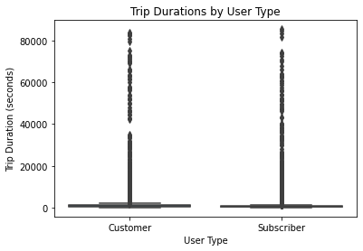

```python
sb.boxplot(data=df1, x="user_type", y="duration_sec")

plt.title("Trip Durations by User Type")
plt.xlabel("User Type")
plt.ylabel("Trip Duration (seconds)")

plt.show()
```

Because we have outliers on the duration_sec columns we cant get a good box plot so we need to filter out the outliers

```python
# Calculate the first and third quartiles of duration_sec
q1 = df1["duration_sec"].quantile(0.25)
q3 = df1["duration_sec"].quantile(0.75)

# Calculate the IQR of duration_sec
iqr = q3 - q1

# Define the lower and upper bounds for outliers
lower_bound = q1 - 1.5 * iqr
upper_bound = q3 + 1.5 * iqr

# Filter out the outliers of duration_sec
df2 = df1[(df1["duration_sec"] >= lower_bound) & (df1["duration_sec"] <= upper_bound)]
```

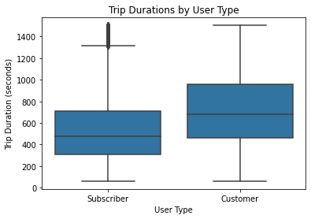

```python
sb.boxplot(data=df2, x="user_type", y="duration_sec",color=default_color)

plt.title("Trip Durations by User Type")
plt.xlabel("User Type")
plt.ylabel("Trip Duration (seconds)")

plt.show()
```

We can clearly see that the customer type has a higher mean trip duration than the subscriber

> In terms of the Ford GoBike System Data, the "Subscriber" user type refers to users who have purchased a bike sharing membership, while the "Customer" user type refers to users who have rented a bike without purchasing a membership.

### What is the average trip duration for the top 5 start stations

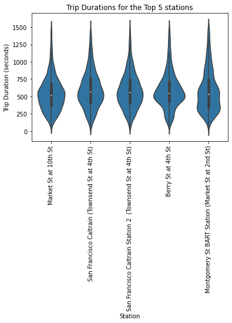

```python
# Get the most popular start and end stations
n = 5
top_start_stations = df2['start_station_name'].value_counts().nlargest(n).index
top_end_stations = df2['end_station_name'].value_counts().nlargest(n).index
# Filter the data to include only trips that start or end at the most popular stations
df_top_stations = df2[(df2['start_station_name'].isin(top_start_stations))]

sb.violinplot(data=df_top_stations, x="start_station_name", y="duration_sec",color=default_color)

plt.title("Trip Durations for the Top 5 stations")
plt.xlabel("Station")
plt.ylabel("Trip Duration (seconds)")
plt.xticks(rotation=90)
plt.show()
```

We can notice that Berry St at 4th St station has a higher distribution in term of trip duration while Montgomery St BART Station (Market St at 2nd St) station has a little bit lower distribution in term of trip duration

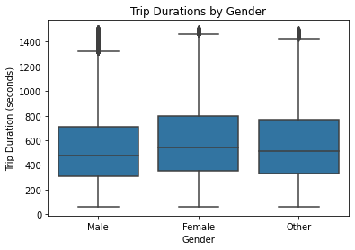

```python
sb.boxplot(data=df2, x="member_gender", y="duration_sec",color=default_color)

plt.title("Trip Durations by Gender")
plt.xlabel("Gender")
plt.ylabel("Trip Duration (seconds)")

plt.show()
```

We can notice that Females have the highest mean trip duration and Males have the lowest mean trip duration, honestly I don't know why, I thought it would be the inverse because to me it seems that males love riding bikes.

### What is the trip duration by bike sharing

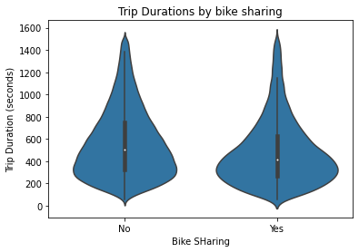

```python
sb.violinplot(data=df2, x="bike_share_for_all_trip", y="duration_sec",color=default_color)

plt.title("Trip Durations by bike sharing")
plt.xlabel("Bike SHaring")
plt.ylabel("Trip Duration (seconds)")

plt.show()
```

We see clearly that the trips without bike sharing has higher possiblility to be longer in term of duration than the trips with bike sharing

> **bike_share_for_all_trip** is a column in the Ford GoBike System dataset that indicates whether the user who took the trip was enrolled in the "Bike Share for All" program. This program is designed to provide low-income residents with affordable access to bike share systems in order to promote transportation equity. Users who are enrolled in this program may have different usage patterns or trip characteristics compared to users who are not enrolled.

### What is the relation between Start Hour and Trip duration

```python
df2.columns
```

```
Index(['duration_sec', 'start_time', 'end_time', 'start_station_id',
       'start_station_name', 'start_station_latitude',
       'start_station_longitude', 'end_station_id', 'end_station_name',
       'end_station_latitude', 'end_station_longitude', 'bike_id', 'user_type',
       'member_birth_year', 'member_gender', 'bike_share_for_all_trip',
       'start_hour', 'start_week_day', 'member_age', 'member_age_range'],
      dtype='object')
```

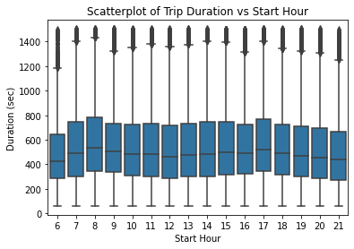

```python
# Create a scatterplot of duration_sec vs start_year
sb.boxplot(data=df2, x="start_hour", y="duration_sec",color=default_color)


# Set the plot labels
plt.xlabel('Start Hour')
plt.ylabel('Duration (sec)')
plt.title('Scatterplot of Trip Duration vs Start Hour')

# Display the plot
plt.show()
```

We can see that 6am and 7am trips has lower duration trips and this is because it's too early to go in a long trip may be, while we can see that from 8am to 5pm we almost have the same mean trip duration with slight decrease in the midday.

### What is the distribution of trips for top stations during day hours

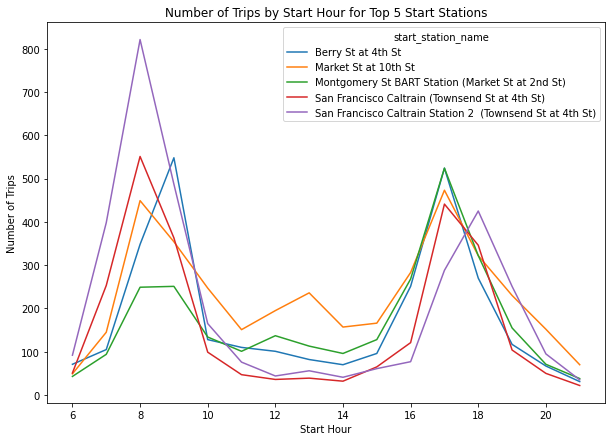

```python
# Get the top 5 start stations
top_5_start_stations = df2['start_station_name'].value_counts().nlargest(5).index

# Create a subset of the data with only the top 5 start stations
df_top_5 = df2[df2['start_station_name'].isin(top_5_start_stations)]

# Create a groupby object by start station and hour, and count the number of trips per hour for each start station
hourly_trips_top_5 = df_top_5.groupby(['start_station_name', 'start_hour']).size()

# Reset the index to turn the grouped data into a DataFrame
hourly_trips_top_5 = hourly_trips_top_5.reset_index(name='count')
plt.figure(figsize=[10, 7])

# Create a line plot for each start station using seaborn
sb.lineplot(data=hourly_trips_top_5, x='start_hour', y='count', hue='start_station_name')

# Set the plot labels and title
plt.xlabel("Start Hour")
plt.ylabel("Number of Trips")
plt.title("Number of Trips by Start Hour for Top 5 Start Stations")

# Show the plot
plt.show()
```

### Relation between trip duration and days of the week

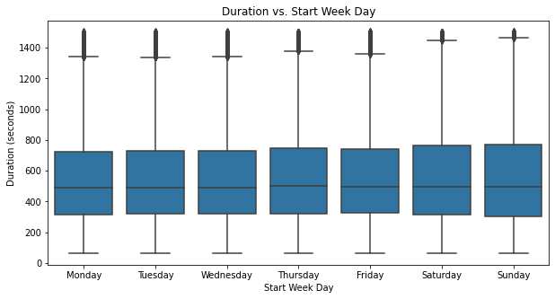

```python
# Define the plot size
plt.figure(figsize=(10, 5))

# Create the scatter plot
sb.boxplot(data=df2, x="start_week_day", y="duration_sec",color=default_color)

# Add axis labels and plot title
plt.xlabel("Start Week Day")
plt.ylabel("Duration (seconds)")
plt.title("Duration vs. Start Week Day")

# Show the plot
plt.show()
```

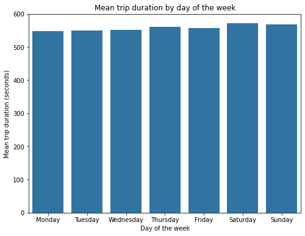

```python
# Group the data by start_week_day and calculate the mean of duration_sec
duration_by_day = df2.groupby('start_week_day')['duration_sec'].mean()

# Plot the mean trip duration for each day of the week
plt.figure(figsize=(8,6))
sb.barplot(x=duration_by_day.index, y=duration_by_day.values, color=default_color)
plt.xlabel('Day of the week')
plt.ylabel('Mean trip duration (seconds)')
plt.title('Mean trip duration by day of the week')
plt.show()
```

We can clearly see that there is no relation between trip duration and days of the week, just a little increase of mean duration during the weekend. Next: I want to see the pairwise correlations present between features in the data using a matrix and heatmap

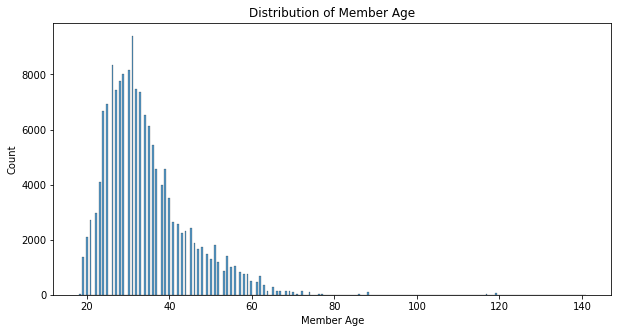

```python
plt.figure(figsize=(10,5))
sb.histplot(data=df2, x='member_age', color=sb.color_palette()[0])
plt.xlabel('Member Age')
plt.ylabel('Count')
plt.title('Distribution of Member Age')
plt.show()
```

There are some outliers on the member_age column that we need to filter it out

```python
# Calculate member age
df_filtered = df2[(df2['member_age'] >= 18) & (df2['member_age'] <= 95)]
```

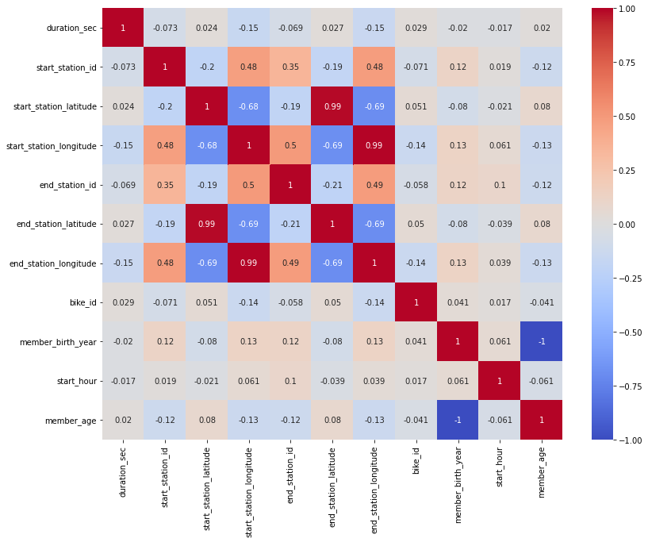

```python
# Calculate the correlation matrix
corr_matrix = df_filtered.corr()
plt.figure(figsize=[13,10])
# Create a heatmap plot
sb.heatmap(corr_matrix, annot=True, cmap='coolwarm')
```

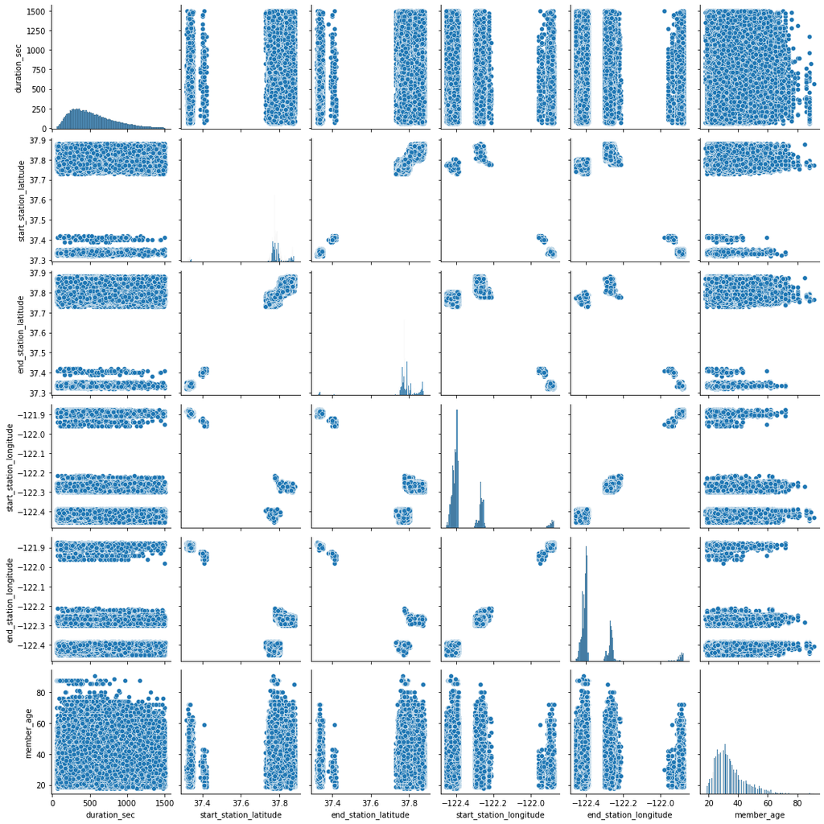

```python
# Create a subset of the dataset with relevant columns
subset = df_filtered[['duration_sec', 'start_station_latitude', 'end_station_latitude','start_station_longitude','end_station_longitude', 'member_age']]

# Use the pairplot function to generate the plot matrix
sb.pairplot(subset)

# Display the plot
plt.show()
```

We can see that there are a few scatterplots that contain a correlation, we can mention the strong positive correlation between **start_station_longitude** and **end_station_longitude** , this correlation is explicable, because the start station should be the same as the end station, the same for **start_station_latitude** and **end_station_latitude**, we have also a relation. these correlations has no useful information so we wont focus on them.

### What is the hourly usage trends by user type

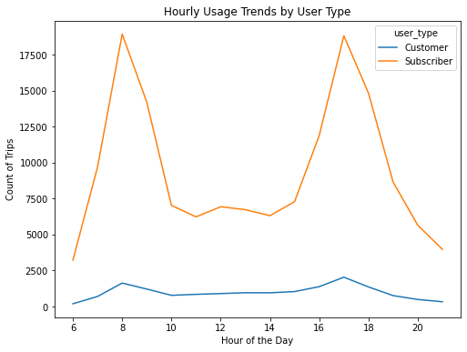

```python
# Group the data by start_hour and user_type, and count the number of trips
df_grouped = df2.groupby(['start_hour', 'user_type']).size().reset_index(name='count')

# Pivot the table to have separate columns for each user_type
df_pivot = df_grouped.pivot(index='start_hour', columns='user_type', values='count')

# Create a line plot with separate lines for each user type
df_pivot.plot(kind='line', figsize=(8, 6))

# Set the plot title and labels
plt.title('Hourly Usage Trends by User Type')
plt.xlabel('Hour of the Day')
plt.ylabel('Count of Trips')

# Show the plot
plt.show()
```

This plot shows no useful information because there is a huge difference in term of instance counts for the user type (Subscriber type has the most instances) so it could be useful to plot Hourly usage trends by user type using the mean trip duration instead of trips count (we will see this plot in the multivariate section)

### Relation between user type, member gender and bike share for all trip

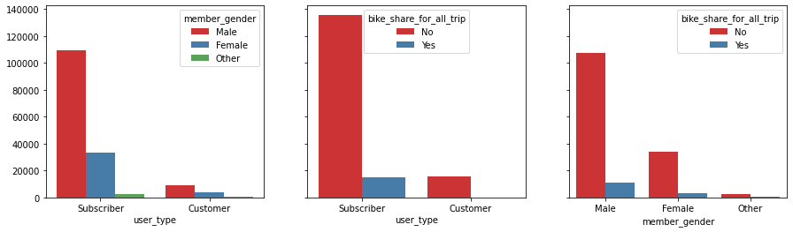

```python
fig, axs = plt.subplots(ncols=3, figsize=(15,4), sharey=True)

sb.countplot(data = df2, x = 'user_type', hue = 'member_gender', palette = 'Set1', ax=axs[0])
sb.countplot(data = df2, x = 'user_type', hue = 'bike_share_for_all_trip', palette = 'Set1', ax=axs[1])
sb.countplot(data = df2, x = 'member_gender', hue = 'bike_share_for_all_trip', palette = 'Set1', ax=axs[2])

# Remove y-axis label on the left side of subplots
axs[0].set_ylabel('')
axs[1].set_ylabel('')
axs[2].set_ylabel('')



plt.show()
```

### Did you observe any interesting relationships between the other features (not the main feature(s) of interest)?

> No, I didn't notice something special.

## Multivariate Exploration

### Relation between trip duration and the other columns

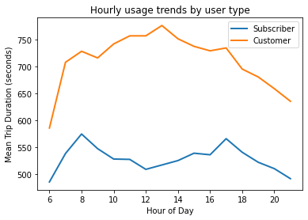

```python
# Filter the data by user type
subscriber_data = df2[df2['user_type'] == 'Subscriber']
customer_data = df2[df2['user_type'] == 'Customer']

# Calculate the mean trip duration by hour for each user type
subscriber_duration_by_hour = subscriber_data.groupby('start_hour')['duration_sec'].mean()
customer_duration_by_hour = customer_data.groupby('start_hour')['duration_sec'].mean()

# Create a line plot using seaborn
plt.plot(subscriber_duration_by_hour.index, subscriber_duration_by_hour.values, label='Subscriber', linewidth=2)
plt.plot(customer_duration_by_hour.index, customer_duration_by_hour.values, label='Customer', linewidth=2)

# Set the plot labels
plt.xlabel('Hour of Day')
plt.ylabel('Mean Trip Duration (seconds)')
plt.title('Hourly usage trends by user type')
plt.legend()

# Show the plot
plt.show()
```

Customer type has higher mean trip duration during all the hours of the day than subscriber type. This is because the customer type is one paid trip.

### Average trip duration during day hours for each gender

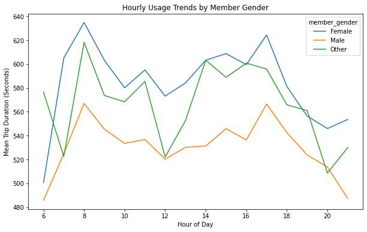

```python
# group the data by start_hour and member_gender, and calculate the mean trip duration
grouped = df2.groupby(['start_hour', 'member_gender']).mean()['duration_sec'].reset_index()
plt.figure(figsize=[10,6])
# plot the data using seaborn
sb.lineplot(data=grouped, x='start_hour', y='duration_sec', hue='member_gender')

# set the plot labels and title
plt.xlabel("Hour of Day")
plt.ylabel("Mean Trip Duration (Seconds)")
plt.title("Hourly Usage Trends by Member Gender")

# show the plot
plt.show()
```

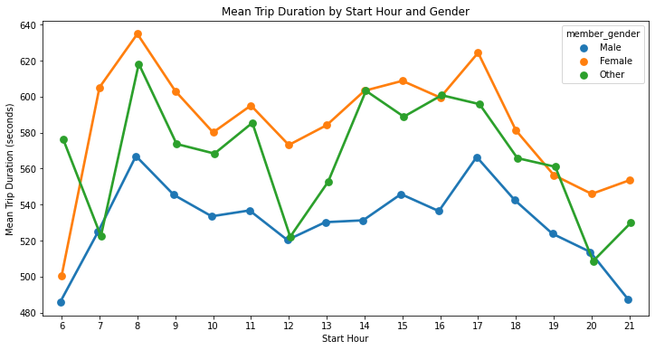

```python
plt.figure(figsize=[12,6])
sb.pointplot(data=df2, x='start_hour', y='duration_sec', hue='member_gender', ci=None, dodge=True)
plt.title('Mean Trip Duration by Start Hour and Gender')
plt.xlabel('Start Hour')
plt.ylabel('Mean Trip Duration (seconds)')
plt.show()
```

There is nothing remark

### Average member age for member gender during hour day

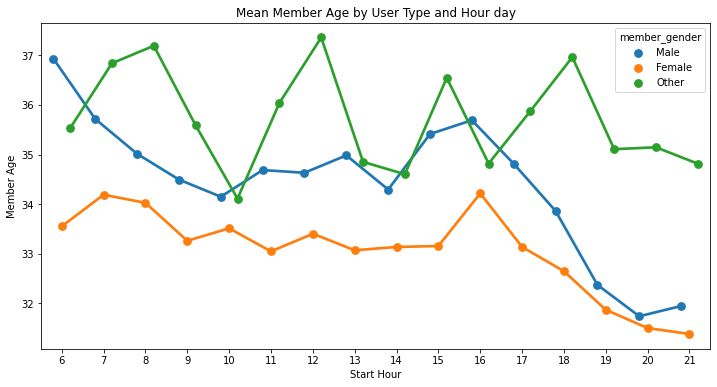

```python
plt.figure(figsize=[12,6])
sb.pointplot(data=df2, x='start_hour', y='member_age', hue='member_gender', dodge=0.4, ci=None)
plt.xlabel('Start Hour')
plt.ylabel('Member Age')
plt.title('Mean Member Age by User Type and Hour day')
plt.show()
```

Nothing to remark.

### Average member age by User Type during Hour of the Day & Days of week

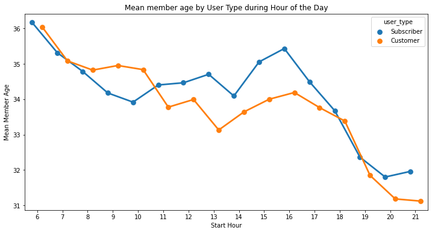

```python
plt.figure(figsize=[12,6])
sb.pointplot(data=df2, x='start_hour', y='member_age', hue='user_type', dodge=0.4, ci=None)
plt.xlabel('Start Hour')
plt.ylabel('Mean Member Age')
plt.title('Mean member age by User Type during Hour of the Day')
plt.show()
```

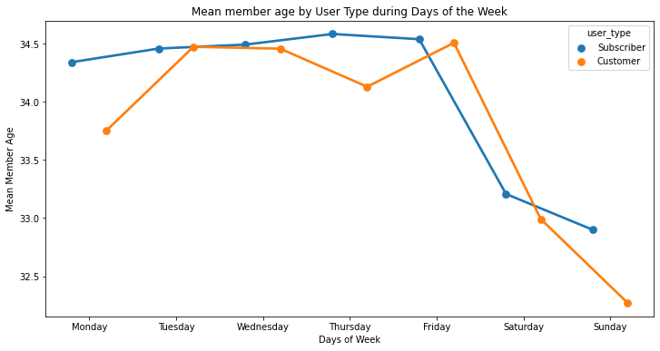

```python
plt.figure(figsize=[12,6])
sb.pointplot(data=df2, x='start_week_day', y='member_age', hue='user_type', dodge=0.4, ci=None)
plt.xlabel('Days of Week')
plt.ylabel('Mean Member Age')
plt.title('Mean member age by User Type during Days of the Week')
plt.show()
```

Mean age decreases in the weekends and the end of the day for both user types

### Trip Duration by User Type and Gender

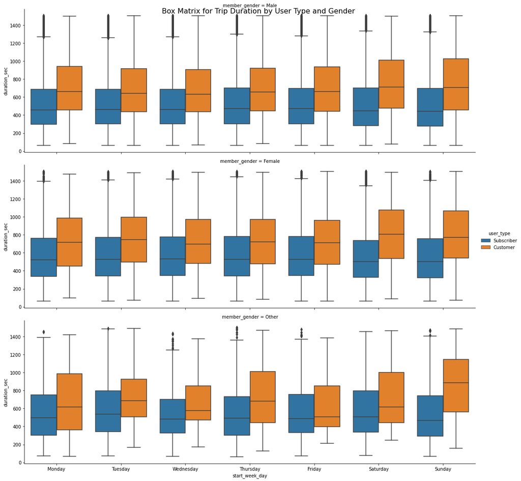

```python
# Define the figure size
plt.figure(figsize=(10,20))

# Create the boxplot matrix
sb.catplot(x="start_week_day", y="duration_sec", hue="user_type", row="member_gender", kind="box",height=5, aspect=3, data=df2)

# Set the plot title
plt.suptitle('Box Matrix for Trip Duration by User Type and Gender', fontsize=16)
```

Mean duration for Customer increases in weekends compared to subscriber type

### Of the features you investigated, were there any unusual distributions? Did you perform any operations on the data to tidy, adjust, or change the form of the data? If so, why did you do this?

> Nothing at all